# Exercise Prediction

## Data Loading and Cleaning

```r
require(randomForest)
traindfraw <- read.csv("pml-training.csv", header = TRUE, na.strings = c("NA", ""))
testdfraw <- read.csv("pml-testing.csv", header = TRUE, na.strings = c("NA", ""))
```

Let’s calculate the percentage of cells missing for each column.

```r
numobs <- nrow(traindfraw)
pctmissing <- sapply(traindfraw, function(x) sum(is.na(x))/numobs)
table(pctmissing)
```

```
## pctmissing
##                 0 0.979308938946081
##                60               100
```

Many features seem to be largely missing (many features are NA around 98% of the time). We can forget these features. We also want to lose timestamp features (do not want to make this a time series thing). We also remove “X” which is just a row number and the window variables which give no insight in the movement of the exercise. All that remains are what we want: physical measurements of exercise movement.

```r
traindf <- traindfraw[,pctmissing<.96]
traindf <- traindf[,!(colnames(traindf) %in% c("X", "raw_timestamp_part_1", "raw_timestamp_part_2", "cvtd_timestamp", "new_window", "num_window"))]

testdf <- testdfraw[,pctmissing<.96]
testdf <- testdf[,!(colnames(testdf) %in% c("X", "raw_timestamp_part_1", "raw_timestamp_part_2", "cvtd_timestamp", "new_window", "num_window"))]
```

## Model Creation

We create a random forests model which predicts the class from the variables that have not been dropped.

```r
set.seed(6863)
themodel <- randomForest(traindf[,!(colnames(traindf) %in% c("classe"))], traindf[,"classe"], importance=T)
```

Now let’s look at the confusion matrix and OOB estimate of the error rate.

```r
print(themodel)
```

```
##
## Call:
##  randomForest(x = traindf[, !(colnames(traindf) %in% c("classe"))],      y = traindf[, "classe"], importance = T)
##                Type of random forest: classification
##                      Number of trees: 500
## No. of variables tried at each split: 7
##
##         OOB estimate of  error rate: 0.26%
## Confusion matrix:
##      A    B    C    D    E  class.error
## A 5578    1    0    0    1 0.0003584229
## B    7 3787    3    0    0 0.0026336582
## C    0   10 3410    2    0 0.0035067212
## D    0    0   20 3194    2 0.0068407960
## E    0    0    0    5 3602 0.0013861935
```

It appears that our model will perform quite well on the test set: the estimate of the error rate is 0.26% which is very low.

Note that because we use random forests, there is no need to separately perform cross-validation. The error rate reported is unbiased (constructed while fitting the model using observations that are not being utilized in the current tree).

We can also plot variable importance (not part of the assignment, just interested).

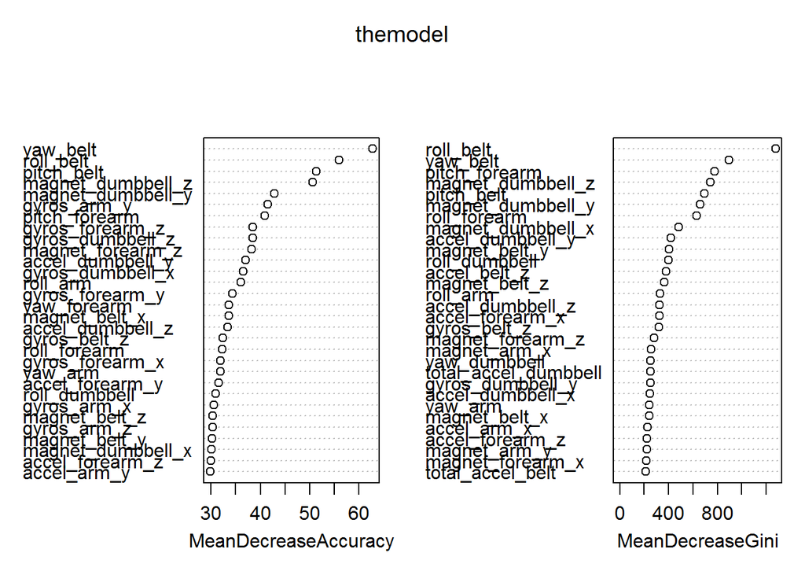

```r
varImpPlot(themodel)
```